# Cmsc320FinalTutorial

Amir Oyolola CMSC320 Final Project

Introduction:

With the raving sensation of the Fifa World Cup currently happening the stir of soccer is at its peak. People around the globe right now are tuned in and loving the senstation it brings. Most places you go, you will see people talking about or streaming the games. But the biggest question is that is on everyones mind is - Who will win the Fifa World Cup. Will it be Brazil, Ghana, Argentina, or another country? The eagerness and excitement rages on the world watches every game euphoria, and hope that their respective team will win. But what if it was possible to simply know who would win the World Cup. This tutorial walks through analyzation of Fifa World Cup data and seeing if its possible to predict who will win the Fifa World Cup of 2022

Motivation:

This tutorial has two primary methods of motivation. The first is the sports climate of the present day. Right now everyone is talking about the World Cup and it has a growing excitement. This excitement has rejuvenated my interest in soccer and I have found myself keeping up to date with scores, and the phenomenal goals scored during this tournament. In addition to the ongoing excitement, another prime reason why I have decided to do a tutorial proposing who will win the world cup is for a new ongoing anime that I am really interested in that revolves around soccer and the World Cup. In the anime, 300 highschoolers want to play for Japan's national team and be the striker that takes Japan and wins the World Cup. The only caveat only 1 can come out of the rigorous training facility denoted Blue Lock, the rest are forced to give up on their soccer goals and can never represent Japan. These two aspects currently happening right now has lead me into doing a project about soccer.

Here's a link to learn more about the World Cup: https://www.roadtrips.com/luxury-travel-guides/world-cup-ultimate-guide/ Here's a link to learn more about the anime Blue Lock: https://en.wikipedia.org/wiki/Blue_Lock

Data Scraping:

We are using a dataset from Kaggle.com (https://www.kaggle.com/datasets/abecklas/fifa-world-cup?resource=download), this data is already in a nice format for us to use and manage. Often times than not however, datasets have missing data, bad column names, and you must do alot of scraping to ensure that the data is available to be used correctly. Here is a link where you can learn alot more about scraping and making your datasets usable: https://towardsdatascience.com/so-youve-got-a-dataset-here-s-how-you-clean-it-5d0b04a2ed86

```python
#imports that will help us
import pandas as pd
import numpy as np
import matplotlib.pyplot as plt
import seaborn as sns
# reading in the world cup data
world_cup_data = pd.read_csv('WorldCups.csv')
#reading in the world cup match data
world_cup_match_data = pd.read_csv('WorldCupMatches.csv')
#readiing in the world cup players
world_cup_player_data = pd.read_csv('WorldCupPlayers.csv')
```

```python
#displaying each of the datasets to ensure proper importations
world_cup_data.head()
```

|  | Year | Country | Winner | Runners-Up | Third | Fourth | GoalsScored | QualifiedTeams | MatchesPlayed | Attendance |
| --- | --- | --- | --- | --- | --- | --- | --- | --- | --- | --- |
| 0 | 1930 | Uruguay | Uruguay | Argentina | USA | Yugoslavia | 70 | 13 | 18 | 590.549 |
| 1 | 1934 | Italy | Italy | Czechoslovakia | Germany | Austria | 70 | 16 | 17 | 363.000 |
| 2 | 1938 | France | Italy | Hungary | Brazil | Sweden | 84 | 15 | 18 | 375.700 |
| 3 | 1950 | Brazil | Uruguay | Brazil | Sweden | Spain | 88 | 13 | 22 | 1.045.246 |
| 4 | 1954 | Switzerland | Germany FR | Hungary | Austria | Uruguay | 140 | 16 | 26 | 768.607 |

```python
world_cup_match_data.head()
```

|  | Year | Datetime | Stage | Stadium | City | Home Team Name | Home Team Goals | Away Team Goals | Away Team Name | Win conditions | Attendance | Half-time Home Goals | Half-time Away Goals | Referee | Assistant 1 | Assistant 2 | RoundID | MatchID | Home Team Initials | Away Team Initials |
| --- | --- | --- | --- | --- | --- | --- | --- | --- | --- | --- | --- | --- | --- | --- | --- | --- | --- | --- | --- | --- |
| 0 | 1930.0 | 13 Jul 1930 - 15:00 | Group 1 | Pocitos | Montevideo | France | 4.0 | 1.0 | Mexico |  | 4444.0 | 3.0 | 0.0 | LOMBARDI Domingo (URU) | CRISTOPHE Henry (BEL) | REGO Gilberto (BRA) | 201.0 | 1096.0 | FRA | MEX |
| 1 | 1930.0 | 13 Jul 1930 - 15:00 | Group 4 | Parque Central | Montevideo | USA | 3.0 | 0.0 | Belgium |  | 18346.0 | 2.0 | 0.0 | MACIAS Jose (ARG) | MATEUCCI Francisco (URU) | WARNKEN Alberto (CHI) | 201.0 | 1090.0 | USA | BEL |
| 2 | 1930.0 | 14 Jul 1930 - 12:45 | Group 2 | Parque Central | Montevideo | Yugoslavia | 2.0 | 1.0 | Brazil |  | 24059.0 | 2.0 | 0.0 | TEJADA Anibal (URU) | VALLARINO Ricardo (URU) | BALWAY Thomas (FRA) | 201.0 | 1093.0 | YUG | BRA |
| 3 | 1930.0 | 14 Jul 1930 - 14:50 | Group 3 | Pocitos | Montevideo | Romania | 3.0 | 1.0 | Peru |  | 2549.0 | 1.0 | 0.0 | WARNKEN Alberto (CHI) | LANGENUS Jean (BEL) | MATEUCCI Francisco (URU) | 201.0 | 1098.0 | ROU | PER |
| 4 | 1930.0 | 15 Jul 1930 - 16:00 | Group 1 | Parque Central | Montevideo | Argentina | 1.0 | 0.0 | France |  | 23409.0 | 0.0 | 0.0 | REGO Gilberto (BRA) | SAUCEDO Ulises (BOL) | RADULESCU Constantin (ROU) | 201.0 | 1085.0 | ARG | FRA |

```python
world_cup_player_data.head()
```

|  | RoundID | MatchID | Team Initials | Coach Name | Line-up | Shirt Number | Player Name | Position | Event |
| --- | --- | --- | --- | --- | --- | --- | --- | --- | --- |
| 0 | 201 | 1096 | FRA | CAUDRON Raoul (FRA) | S | 0 | Alex THEPOT | GK | NaN |
| 1 | 201 | 1096 | MEX | LUQUE Juan (MEX) | S | 0 | Oscar BONFIGLIO | GK | NaN |
| 2 | 201 | 1096 | FRA | CAUDRON Raoul (FRA) | S | 0 | Marcel LANGILLER | NaN | G40' |
| 3 | 201 | 1096 | MEX | LUQUE Juan (MEX) | S | 0 | Juan CARRENO | NaN | G70' |
| 4 | 201 | 1096 | FRA | CAUDRON Raoul (FRA) | S | 0 | Ernest LIBERATI | NaN | NaN |

Okay great now we have our datasets in stored this is great. We did not necessarily have to do anything with the data so far, in terms of managing but lets check if varianbles we wish to use are the correct type of object.

```python
print(world_cup_data['Attendance'].dtype)
print(world_cup_match_data['Attendance'].dtype)
```

```
object
float64
```

UH-OH the world_cup_data Attendance is not in a number format. This will make computations where we compare using this metric hard. It looks like the world_cup_match_data has it in a format that is manageable however. Lets convert the world_cup_data into a type we can work with.

```python
#First we must convert the periods to commas

world_cup_data['Attendance']= world_cup_data["Attendance"].astype(str)
world_cup_data['Attendance']= world_cup_data["Attendance"].str.replace('.','', regex = True)
#Now lets convert this val to a float
world_cup_data['Attendance']= world_cup_data["Attendance"].astype(int)
```

```python
print(world_cup_data['Attendance'].dtype)
```

```
int64
```

```python
#Woohoo we now can see that we have gotten the attendance variable to be something we can work it
```

Now that we have attendance in variables that we need lets start analyzing!

Data Management/Representation/Exploratory data analysis/Communication of Insights attained/

Trends are very common in sports, usually when you win in a previous year its very common to win again, and again. So lets see from this data which country has the most wins.

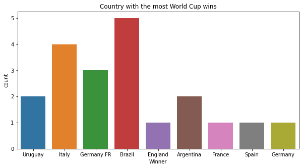

```python
#Making a plot to see which country has the most wins
plt.figure(figsize = (10,5))
plt.title("Country with the most World Cup wins")
plt.xlabel("Countries")
plt.ylabel("Wins")
sns.countplot(x =world_cup_data['Winner'], linewidth =2.5)
plt.show()
```

Upon looking we see there are two Germanys. Oh no! Lets change "Germany FR" to Germany and rerun

```python
world_cup_data = world_cup_data.replace(['Germany FR'],'Germany')
```

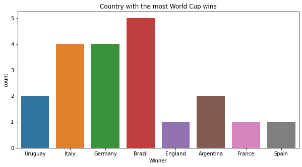

```python
plt.figure(figsize =(10,5))
plt.title("Country with the most World Cup wins")
plt.xlabel("Countries")
plt.ylabel("Wins")
sns.countplot(x =world_cup_data['Winner'], linewidth =2)
plt.show()
```

Exploratory data analysis and Communication of Insights attained

From this data analyzation use matplot and seaborn we are able to see that Brazil has the most world cup wins! This statisitc shows us that Brazil is usually very good and can continue to get through multiple soccer matches and win the tourrnament. From this it would be a good prediction to say that Brazil has a high chance of winning the world cup. Following Brazil we see that Germany and Italy are aslo great predictors for winning the world cup.

However this bar graph is an indicator of more than just the top 3 countries most likely to win. It tells us the top 8! Winning even one world cup is a phenonemon and it gives the country the experience of making it through a multitude of rigourous matches. For this dataset, it goes to 2014, but in the world cup for 2018 England one. And as of today Argentina is in the final match. So for for these 8 teams if we were to predict that they would be a winner it would be a good assumption.

But lets keep analyzing!! Since I am a renewed soccer fan I want to see if there is a correlation to how many people over the years went to these matches. For example should the number of attendees be increasing over the years or decreasing. Doing this analysis will allow us to phrase qurestions which enable us to figure out possible trends

More Data Analyzation and Communication of Insights attained

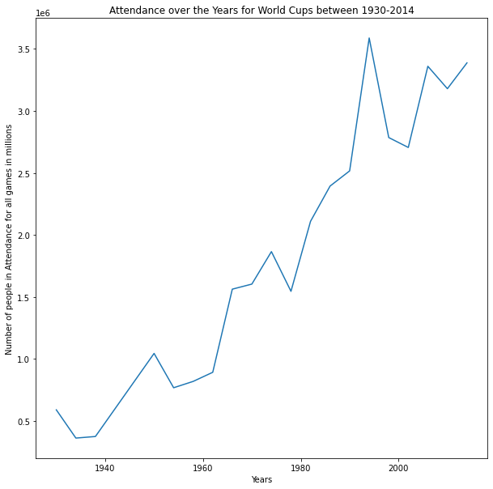

```python
#Lets look at a trend of the attendance over the years
#Making a new dataframe with just the relevant information we need to do our analysis
year_and_attendance = world_cup_data[['Year','Attendance']]
year_and_attendance.head()
plt.figure(figsize = (10,10))
plt.plot(year_and_attendance['Year'], year_and_attendance['Attendance'])
plt.xlabel('Years')
plt.ylabel('Number of people in Attendance for all games in millions')
plt.title('Attendance over the Years for World Cups between 1930-2014')
plt.show()
```

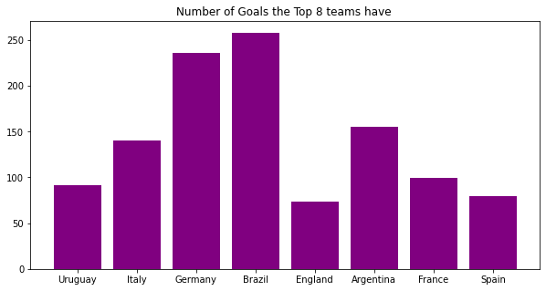

```python
#Identifying top8 teams

world_cup_match_data = world_cup_match_data.replace(['Germany FR'],'Germany')
#Lets do filtering on our data we will make 8 dataframes
uruguay_home = world_cup_match_data[ world_cup_match_data['Home Team Name'] == 'Uruguay']
italy_home = world_cup_match_data[ world_cup_match_data['Home Team Name'] == 'Italy']
germany_home = world_cup_match_data[ world_cup_match_data['Home Team Name'] == 'Germany']
brazil_home = world_cup_match_data[ world_cup_match_data['Home Team Name'] == 'Brazil']
england_home = world_cup_match_data[ world_cup_match_data['Home Team Name'] == 'England']
argentina_home = world_cup_match_data[ world_cup_match_data['Home Team Name'] == 'Argentina']
france_home = world_cup_match_data[ world_cup_match_data['Home Team Name'] == 'France']
spain_home =  world_cup_match_data[ world_cup_match_data['Home Team Name'] == 'Spain']

#sum up all there home goals

uruguay_goals = uruguay_home['Home Team Goals'].sum()
italy_goals = italy_home['Home Team Goals'].sum()
germany_goals =germany_home['Home Team Goals'].sum()
brazil_goals = brazil_home['Home Team Goals'].sum()
england_goals = england_home['Home Team Goals'].sum()
argentina_goals = argentina_home['Home Team Goals'].sum()
france_goals = france_home['Home Team Goals'].sum()
spain_goals = spain_home['Home Team Goals'].sum()

#need to find there away games

#Lets do filtering on our data we will make 8 dataframes
uruguay_away = world_cup_match_data[ world_cup_match_data['Away Team Name'] == 'Uruguay']
italy_away = world_cup_match_data[ world_cup_match_data['Away Team Name'] == 'Italy']
germany_away = world_cup_match_data[ world_cup_match_data['Away Team Name'] == 'Germany']
brazil_away = world_cup_match_data[ world_cup_match_data['Away Team Name'] == 'Brazil']
england_away = world_cup_match_data[ world_cup_match_data['Away Team Name'] == 'England']
argentina_away = world_cup_match_data[ world_cup_match_data['Away Team Name'] == 'Argentina']
france_away= world_cup_match_data[ world_cup_match_data['Away Team Name'] == 'France']
spain_away=  world_cup_match_data[ world_cup_match_data['Away Team Name'] == 'Spain']

#updating for total games
uruguay_goals = uruguay_home['Away Team Goals'].sum() + uruguay_goals
italy_goals = italy_home['Away Team Goals'].sum() + italy_goals
germany_goals =germany_home['Away Team Goals'].sum() + germany_goals
brazil_goals = brazil_home['Away Team Goals'].sum() +brazil_goals
england_goals = england_home['Away Team Goals'].sum() +england_goals
argentina_goals = argentina_home['Away Team Goals'].sum() +argentina_goals
france_goals = france_home['Away Team Goals'].sum() +france_goals
spain_goals = spain_home['Away Team Goals'].sum() +spain_goals
#making a dictionary of the 8 teams with their goals
dict = { 'Country' : [ 'Uruguay', 'Italy', 'Germany', 'Brazil', 'England', 'Argentina', 'France', 'Spain'],
        'Goals' : [ uruguay_goals,italy_goals,germany_goals, brazil_goals,  england_goals, argentina_goals, france_goals,spain_goals]

}

# Now lets make this dictionary a new dataframe
goals_for_top8 = pd.DataFrame.from_dict(dict)
data_x = list(dict.keys())
data_y = list(dict.values())


plt.figure(figsize = (10,5))
plt.title("Number of Goals the Top 8 teams have ")
data_xreal =data_y[0]
data_yreal =data_y[ 1]
plt.bar(data_xreal,data_yreal, color = 'purple')
plt.show()
```

Lets compare this to an average of three countries not in the top 8 lets compare them to the top 8 goals

[figure not shown]

```
[26.0, 22.0, 48.0]
```

```python
nigeria_home = world_cup_match_data[ world_cup_match_data['Home Team Name'] == 'Nigeria']
scotland_home = world_cup_match_data[ world_cup_match_data['Home Team Name'] == 'Scotland']
austria_home = world_cup_match_data[ world_cup_match_data['Home Team Name'] == 'Austria']

#sum up all there home goals

nigeria_goals = nigeria_home['Home Team Goals'].sum()
scotland_goals = scotland_home['Home Team Goals'].sum()
austria_goals = austria_home['Home Team Goals'].sum()

#need to find there away games
nigeria_away = world_cup_match_data[ world_cup_match_data['Away Team Name'] == 'Nigeria']
scotland_away  = world_cup_match_data[ world_cup_match_data['Away Team Name'] == 'Scotland']
austria_away  = world_cup_match_data[ world_cup_match_data['Away Team Name'] == 'Austria']

#updating for total games
nigeria_goals = nigeria_home['Away Team Goals'].sum() + nigeria_goals
scotland_goals = scotland_home['Away Team Goals'].sum() + scotland_goals
austria_goals = austria_home['Away Team Goals'].sum() + austria_goals

#making a dictionary of the 8 teams with their goals
dict2 = { 'Country' : [ 'Nigeria','Scotland','Austria'],
        'Goals' : [ nigeria_goals,scotland_goals,austria_goals]
}

# Now lets make this dictionary a new dataframe
goals_for_top8 = pd.DataFrame.from_dict(dict2)
data_x2 = list(dict2.keys())
data_y2 = list(dict2.values())
plt.figure(figsize = (10,5))
plt.title("Number of Goals the Top 8 teams have ")
data_xreal2 =data_y2[0]
data_yreal2 =data_y2[ 1]
plt.bar(data_xreal2,data_yreal2, color = 'orange')
#Nigeria has goals of 26, Scotland has goals of 22, and Austria has goals of 48. (26+22+48)/3 = 32
plt.bar('Average',32)

plt.show()
data_yreal2
```

Now lets add this average to the original dataset so we can compare the average of three random countires to the top8

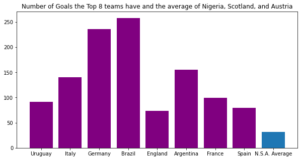

```python
plt.figure(figsize = (10,5))
plt.title("Number of Goals the Top 8 teams have and the average of Nigeria, Scotland, and Austria")
data_xreal =data_y[0]
data_yreal =data_y[ 1]
plt.bar(data_xreal,data_yreal, color = 'purple')
#N.S.A -> Stands for Nigeria, Scotland and Austria
plt.bar('N.S.A. Average', 32)
plt.show()
```

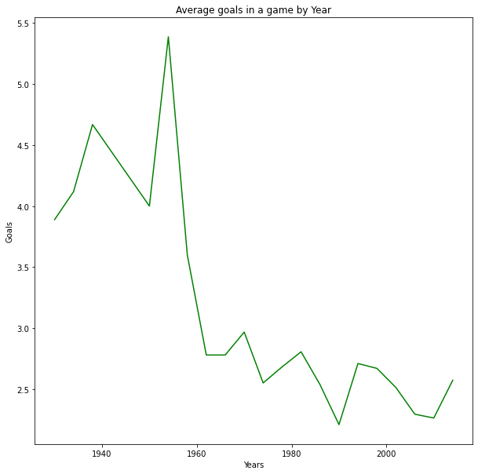

```python
#We need to get the total goals for all games
#Lets make a new col that has total goals and the years
world_cup_match_data['Total Goals'] = world_cup_match_data['Home Team Goals'] +world_cup_match_data['Away Team Goals']
#Now we need to group by year for our analysis
grouped_years = world_cup_match_data[['Total Goals', 'Year']].groupby('Year')
goals_years = grouped_years['Total Goals'].sum()

games_year = world_cup_match_data['Year'].value_counts()

avg_goals_in_game_by_year = goals_years/games_year


#Lets make a plot to show how total goals are been

plt.figure(figsize = (10,10))
plt.plot(avg_goals_in_game_by_year,color = 'green')
plt.title('Average goals in a game by Year')
plt.xlabel('Years')
plt.ylabel('Goals')
plt.show()
```

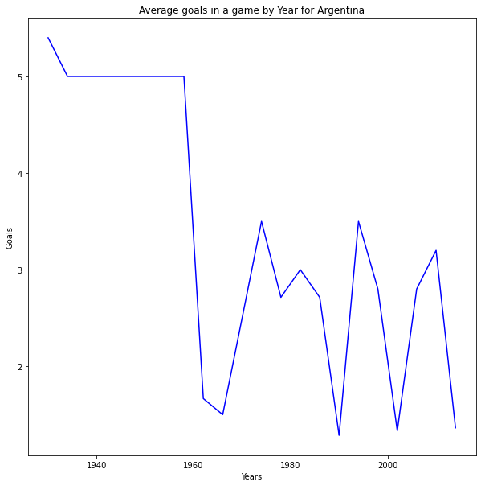

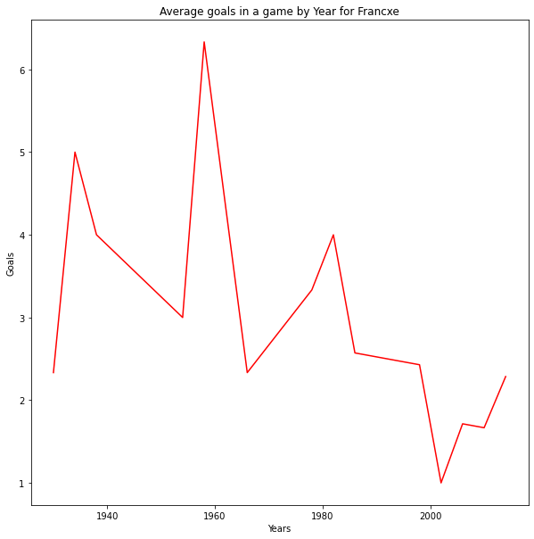

```python
#For Argentina and France

#Argentina data

#Argentina complete dataframe with both away and home data
argentina_complete = pd.concat([argentina_home,argentina_away])
argentina_complete['Total Goals'] = argentina_complete['Home Team Goals'] +argentina_complete['Away Team Goals']

#Calculation average goals in a game per year specifically for argentina
grouped_years_argentina = argentina_complete[['Total Goals', 'Year']].groupby('Year')
goals_years_argentina = grouped_years_argentina['Total Goals'].sum()

games_year_argentina = argentina_complete['Year'].value_counts()

avg_goals_in_game_by_year_argentina = goals_years_argentina/games_year_argentina


#plotting the data for argentina
plt.figure(figsize = (10,10))
plt.plot(avg_goals_in_game_by_year_argentina,color = 'blue')
plt.title('Average goals in a game by Year for Argentina')
plt.xlabel('Years')
plt.ylabel('Goals')
plt.show()



# France Data
france_complete = pd.concat([france_home,france_away])

france_complete['Total Goals'] = france_complete['Home Team Goals'] +france_complete['Away Team Goals']

#Calculation average goals in a game per year specifically for argentina
grouped_years_france = france_complete[['Total Goals', 'Year']].groupby('Year')
goals_years_france = grouped_years_france['Total Goals'].sum()

games_year_france = france_complete['Year'].value_counts()

avg_goals_in_game_by_year_france = goals_years_france/games_year_france


#plotting the data for argentina
plt.figure(figsize = (10,10))
plt.plot(avg_goals_in_game_by_year_france,color = 'red')
plt.title('Average goals in a game by Year for Francxe')
plt.xlabel('Years')
plt.ylabel('Goals')
plt.show()
```

I hope this tutorial allows you to see the power of data science and be able to make data analyzations of your own in the future!! This tutorial allowed you to perform analyzation to see if it was possible to predict who will win the World Cup. But you can do analyzation on anything. I hope this tutorial allows you to make your own analyzations!

Conclusion and Explanation of all Categories For Reference

Understanding: I walked through my tutorial so that users would know why I did what I did. For example going through the tutorial I explained why the top8 teams with the most world cup are most likely to win again. I then showed that it showed to be true because in the 2022 finals Argentina and France will face of, both teams in the top 8 of ur data analyzation

Prose: Throughout the code, I explain general gist of what we will do with comments and add markdown comments as prose to help enhance users experience.

Code: Code is above throughout the tutorial.

Pipeline: I explain the multiply steps of the pipeline in the tutorial.

Communication of Approach: The reasoning for doing my tutorial like this is to make this as a introductory tutorial. There were many steps that I could of done multiple things in one line or in the same dataframe, but I wanted to make sure that users could fully understand what I was doing in each step so that they can do similar things in their own data analyzations. Some tradeoffs that I want to elaborate are that in my methodology of performing activites one might say that I do things that can be done in one step, however the tradeoff of this is that it is hopefully easier to understand, a key concept I wanted to ensure was in my tutorial.

Formatting and Subjective Evaluation: I made sure to use a mix of comments, markdown blocks to ensure user knows what part of the steps we are doing.

THANK YOU FOR COMING TO MY TUTORIAL I HOPE YOU ENJOYED IT :)